# Inferência parte 1

Nazareno

## Os dados

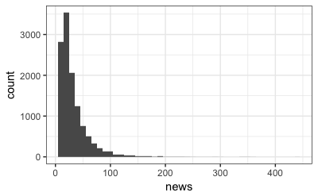

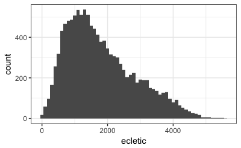

## Amostra e visões a partir dela

Imagine por agora que os dados que temos do Last.fm são completos. Que são a população inteira de usuários. Como seria nossa visão dos dados se tivéssemos apenas uma amostra dos dados? `sample(x, n)` faz uma amostra aleatórioa de `n` elementos tirados do vetor `x`:

Se calcularmos a média do números de novos artistas escutados para três amostras de 100 elementos, teremos 3 resultados diferentes:

```r
sample(lastfm$news, 100) %>% mean()
```

```
[1] 36.35
```

```r
sample(lastfm$news, 100) %>% mean()
```

```
[1] 34.58
```

```r
sample(lastfm$news, 100) %>% mean()
```

```
[1] 34.06
```

Se fizermos isso muitas vezes podemos ver como essa variação acontece. A distribuição dos valores de uma estatística em diferentes amostras de uma população se chama **distribuição amostral** da estatística.

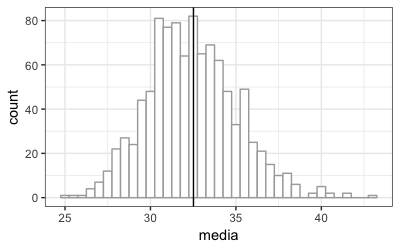

E se o tamanho da amostra (*n*) fosse muito menor?

```r
amostras = data.frame(amostra = 1:1000) %>% # faremos 1000 vezes
  mutate(media = map_dbl(amostra, ~ lastfm %>%
                                      pull(news) %>%
                                      sample(10) %>%
                                      mean()))
amostras
```

| amostra | media |
| --- | --- |
| 1 | 23.1 |
| 2 | 48.3 |
| 3 | 27.4 |
| 4 | 20.9 |
| 5 | 30.4 |
| 6 | 21.7 |
| 7 | 31.2 |
| 8 | 33.2 |
| 9 | 48.5 |
| 10 | 30.6 |

[output cut: 990 more lines]

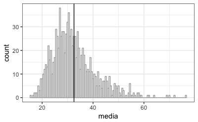

```r
amostras %>%
  ggplot(aes(media)) +
  geom_histogram(binwidth = .5, fill = "white", colour = "darkgrey") +
  geom_vline(xintercept = mean(lastfm$news)) # média calculada com todos os dados
```

```r
amostras = data.frame(amostra = 1:1000) %>% # faremos 1000 vezes
  mutate(estatistica = map_dbl(amostra, ~ lastfm %>%
                                      pull(news) %>%
                                      sample(100) %>%
                                      sd()))
amostras
```

| amostra | estatistica |
| --- | --- |
| 1 | 29.60347 |
| 2 | 30.17968 |
| 3 | 25.01172 |
| 4 | 16.86743 |
| 5 | 43.35536 |
| 6 | 27.57480 |
| 7 | 18.64521 |
| 8 | 23.33523 |
| 9 | 40.03153 |
| 10 | 18.61192 |

[output cut: 990 more lines]

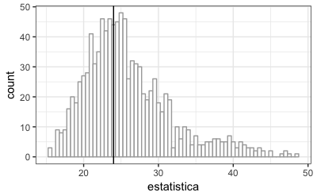

```r
amostras %>%
  ggplot(aes(estatistica)) +
  geom_histogram(binwidth = .5, fill = "white", colour = "darkgrey") +
  geom_vline(xintercept = median(lastfm$news)) # média calculada com todos os dados
```

## Distribuição amostral

A distribuição dos valores de uma estatística a partir de amostras é chamada de *distribuição amostral* daquela estatística. Ela tem um papel importante, porque é a partir do entendimento dela que estimaremos quanta confiança temos em uma estatística que estamos calculando a partir de uma amostra.

O principal a entender aqui é que se conhecermos a distribuição amostral, saberemos quão longe normalmente a estatística calculada para uma amostra está daquela calculada para a população. Sabendo isso, podemos calcular uma margem de erro para a estimativa feita a partir da amostra.

## A situação mais comum na vida real

Normalmente temos *uma amostra* da população apenas. Daí não conhecemos a distribuição amostral. Mas gostaríamos de a partir da nossa amostra estimar onde está a estatística para a população.

Exemplo: queremos estimar qual a proporção de pessoas que gostará do produto (a estatística) entre todos os usuários (a população) a partir do cálculo da proporção de pessoas que gostou do produto (a mesma estatística) em um teste com 100 pessoas (a amostra).

Repare que se conhecermos como a estatística varia na distribuição amostral (ex: 2 pontos pra mais ou pra menos cobrem 99% dos casos) e temos a estatística calculada para a amostra, poderíamos estimar uma faixa de valores onde achamos que a estatística está para a população *com 99% de confiança*.

### A ideia central que usaremos

Não temos a população, para estimar a variação na distribuição amostral. A ideia principal que usaremos, em uma técnica chamada *boostrapping* é que *usar a amostra como substituto da população e simular a amostragem através de reamostragem com reposição fornece uma estimativa precisa da variação na distribuição amostral*.

Pegando por partes:

- Consideramos a amostra $A$ que tem tamanho $n$ como sendo um substituto da população
- Repetimos $b$ vezes o seguinte processo: criamos uma amostra de tamanho $n$ obtendo elementos aleatoriamente de $A$, repondo cada elemento depois de cada sorteio.
- Calculamos a estatística $e$ que nos interessa (média, mediana, desvio padrão, o que for) para cada uma das $b$ amostras.

Como resultado, sabemos como a estatística $e$ varia em uma simulação de $b$ amostragens.

A partir dessa informação, podemos estimar quão longe no máximo a estatística $e_a$ que calculamos para nossa amostra está da estatística $e_p$ para a população. Isso porque se sabemos normalmente quão longe $e_a$ está de $e_p$ (que é o que estimamos com o boostrap), sabemos também o inverso.

Assim, se estimamos que em 99% das amostras, $e_a$ está a +/- 10 unidades de $e_p$, e calculamos que $e_a = 22$, podemos estimar que *com 99% de confiança* $e_p$ está em $e_a +/ - 10 = [12, 32]$.

### Aplicando bootstrapping

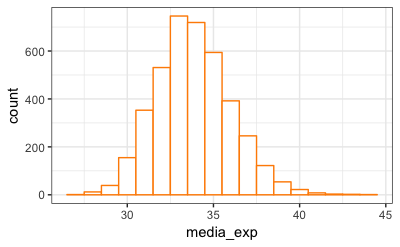

Calculando o IC:

```r
# IC com 90%:
alpha = .1
quantile(experimentos$media_exp,
         probs = c(.05, .95))
```

```
    5%    95%
30.465 37.570
```

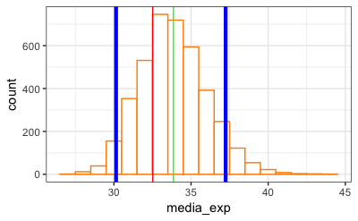

```r
cis = experimentos %>%
    mutate(diferenca = media_exp - media_amostra) %>%
    summarise(l = quantile(diferenca, alpha/2),
              u = quantile(diferenca, 1 - alpha/2)) %>%
    mutate(ci_lower = media_amostra - u,
           ci_upper = media_amostra - l)
ggplot(experimentos, aes(x = media_exp)) +
  geom_histogram(binwidth = 1, colour = "darkorange", fill = "white") +
  geom_vline(aes(xintercept = cis$ci_lower), colour = "blue", size = 1.5) +
  geom_vline(aes(xintercept = cis$ci_upper), colour = "blue", size = 1.5) +
  geom_vline(aes(xintercept = media_amostra), colour = "green") +
    geom_vline(aes(xintercept = mean(lastfm$news)), colour = "red")
```

Com outro nível de confiança:

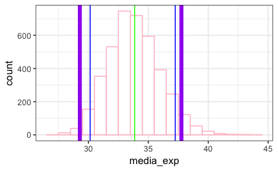

```r
# IC com 95%:
alpha2 = .05
cis2 = experimentos %>%
    mutate(diferenca = media_exp - media_amostra) %>%
    summarise(l = quantile(diferenca, alpha2/2),
              u = quantile(diferenca, 1 - alpha2/2)) %>%
    mutate(ci_lower = media_amostra - u,
           ci_upper = media_amostra - l)
ggplot(experimentos, aes(x = media_exp)) +
  geom_histogram(binwidth = 1, colour = "pink", fill = "white") +
    geom_vline(aes(xintercept = cis$ci_lower), colour = "blue") +
  geom_vline(aes(xintercept = cis$ci_upper), colour = "blue") +
  geom_vline(aes(xintercept = cis2$ci_lower), colour = "purple", size = 2) +
  geom_vline(aes(xintercept = cis2$ci_upper), colour = "purple", size = 2) +
  geom_vline(aes(xintercept = media_amostra), colour = "green")
```